# Project1

Chris Comora

10/15/2019

# Overview

The data being explored comes from the data.gov website and can be found here https://catalog.data.gov/dataset/bicycle-crashes. It contains police-reported information concering motor-vehicle crashes involving pedestrians and bicyclists in the Chapel Hill region of North Carolina.  
This data is in the JSON (JavaScript Object Notation) format. JSON is used for storing and transporting data and “is often used when data is sent from a server to a web page.” (https://www.w3schools.com/whatis/whatis_json.asp).

A JSON file can be confusing to look at, but can be viewed in an application such as notepad. Here is a look at our “bicycle-crashes” data as it appears when viewed in notepad:

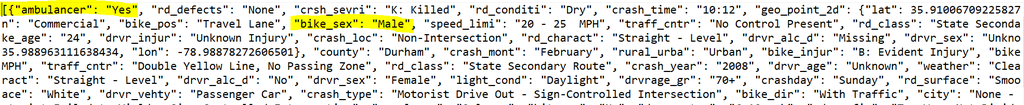

What we see is a lot of name/value pairs, examples of which are highlighted in yellow. The first example shows the name “ambulancer” with a value of “Yes” and the second shows the sex of the bike rider to be male.

# Import data

Our first step is to read in our data using the fromJson() function from the package “jsonlite.” The jsonlite package allows us to convert between JSON and R without any loss of data. I chose this package because I thought it would convert directly to a dataframe but it turned out to be more complicated than that! https://cran.r-project.org/web/packages/jsonlite/vignettes/json-aaquickstart.html

```r
#convert from JSON data to R object (dataframe)
json <- fromJSON("bicycle.json")
#simplify by applying unlist() to the dataframe
my_json <- lapply(json,unlist)
#bind rows back together in matrix format
bicycle <- do.call("rbind", my_json)
#convert back to dataframe and transpose
bicycle_df <- as.data.frame(bicycle)
bicycle_df_trans <- t(bicycle_df)
my_tibble <- tbl_df(bicycle_df_trans)
#convert to html friencly datatable w/ no rownames
my_table <- datatable(bicycle_df_trans,rownames = FALSE,caption = "Table of bicycle crash data")
my_table
```

| ambulancer | rd_defects | crsh_sevri | rd_conditi | crash_time | geo_point_2d | county | crash_mont | rural_urba | bike_injur | bike_race | drvr_vehty | crash_type | bike_dir | city | workzone_i | locality | crashalcoh | excsspdind | bikeage_gr | rd_feature | bike_age | drvr_injur | crash_loc | rd_charact | drvr_alc_d | drvr_sex | light_cond | drvrage_gr | crashday | … |
| --- | --- | --- | --- | --- | --- | --- | --- | --- | --- | --- | --- | --- | --- | --- | --- | --- | --- | --- | --- | --- | --- | --- | --- | --- | --- | --- | --- | --- | --- | --- |
| Yes | None | K: Killed | Dry | 10:12 | 35.9100670922583 | Orange | July | Urban | K: Killed | White | Passenger Car | Motorist Overtaking - Bicyclist Swerved | With Traffic | Carrboro | No | Urban (&gt;70% Developed) | No | No | 70+ | No Special Feature | 70+ | O: No Injury | Non-Intersection | Straight - Level | No | Male | Daylight | 70+ | Saturday | … |
| No | None | C: Possible Injury | Dry | 17:11 | 36.0151171157233 | Orange | February | Rural | C: Possible Injury | White | Passenger Car | Motorist Left Turn - Opposite Direction | With Traffic | None - Rural Crash | No | Rural (&lt;30% Developed) | No | No | 20-24 | Driveway, Private | 24 | Unknown Injury | Non-Intersection | Straight - Level | Missing | Unknown | Daylight | Unknown | Tuesday | … |
| Yes | None | B: Evident Injury | Dry | 19:15 | 35.9889631116384 | Durham | February | Urban | B: Evident Injury | Black | Unknown | Motorist Overtaking - Other / Unknown | With Traffic | Durham | No | Mixed (30% To 70% Developed) | No | No | 25-29 | No Special Feature | 26 | Unknown Injury | Non-Intersection | Straight - Level | Missing | Unknown | Dark - Roadway Not Lighted | Unknown | Tuesday | … |
| Yes | None | B: Evident Injury | Dry | 12:09 | 35.9227900944023 | Orange | December | Urban | B: Evident Injury | White | Passenger Car | Motorist Left Turn - Opposite Direction | With Traffic | Carrboro | No | Urban (&gt;70% Developed) | No | No | 30-39 | T-Intersection | 33 | O: No Injury | Intersection | Straight - Level | No | Female | Daylight | 70+ | Sunday | … |
| Yes | None | B: Evident Injury | Dry | 8:40 | 36.0100771166253 | Durham | September | Rural | B: Evident Injury | White | Passenger Car | Motorist Drive Out - Sign-Controlled Intersection | With Traffic | None - Rural Crash | No | Rural (&lt;30% Developed) | No | No | 40-49 | Four-Way Intersection | 41 | O: No Injury | Intersection | Straight - Grade | No | Male | Daylight | 70+ | Wednesday | … |
| Yes | None | B: Evident Injury | Dry | 15:24 | 35.9361370984618 | Orange | March | Urban | B: Evident Injury | White | Passenger Car | Motorist Drive Out - Sign-Controlled Intersection | Facing Traffic | Chapel Hill | No | Urban (&gt;70% Developed) | No | No | 11-15 | T-Intersection | 12 | O: No Injury | Intersection | Straight - Bottom | No | Male | Daylight | 40-49 | Tuesday | … |
| No | None | O: No Injury | Dry | 18:27 | 35.915937093271 | Orange | April | Urban | Unknown Injury | Unknown/Missing | Passenger Car | Bicyclist Left Turn - Opposite Direction | Facing Traffic | Chapel Hill | No | Urban (&gt;70% Developed) | No | No | Unknown | No Special Feature | 0 | O: No Injury | Non-Intersection | Curve - Grade | No | Male | Daylight | 25-29 | Monday | … |
| Yes | None | O: No Injury | Dry | 20:06 | 35.9219670941575 | Orange | August | Urban | O: No Injury | White | Passenger Car | Motorist Drive Out - Commercial Driveway / Alley | With Traffic | Carrboro | No | Urban (&gt;70% Developed) | No | No | 20-24 | No Special Feature | 23 | O: No Injury | Non-Intersection | Straight - Level | No | Male | Dusk | 50-59 | Friday | … |
| Yes | None | B: Evident Injury | Dry | 15:13 | 35.9374800988954 | Orange | October | Urban | B: Evident Injury | Black | Single Unit Truck (2-Axle, 6-Tire) | Bicyclist Ride Through - Sign-Controlled Intersection | With Traffic | Chapel Hill | No | Rural (&lt;30% Developed) | No | No | 6-10 | Four-Way Intersection | 10 | O: No Injury | Intersection | Straight - Level | No | Male | Daylight | 20-24 | Thursday | … |
| Yes | None | C: Possible Injury | Dry | 20:49 | 36.0331300003281 | Durham | November | Urban | C: Possible Injury | White | Passenger Car | Motorist Overtaking - Undetected Bicyclist | With Traffic | Durham | No | Urban (&gt;70% Developed) | No | No | 40-49 | No Special Feature | 45 | O: No Injury | Non-Intersection | Straight - Level | No | Female | Dark - Roadway Not Lighted | 25-29 | Friday | … |

[output cut: 650 more lines]

# Analysis

We start with plotting the location of the crashes using the ggmap() function. This may help inform our data analysis. For example, why might the crashes be clustered in a certain location?

[figure not shown]

```r
#separate geo coordinates into 2 separate vectors
lat <- my_json$geo_point_2d[1:165]
long <- my_json$geo_point_2d[166:330]
#join vectors together in a matrix and coerce to dataframe
coord <- cbind(lat,long)
coord <- matrix(coord, ncol = 2)
coord_df <- as.data.frame(coord)
#plot map and overlay points representing crashes
p <- ggmap(ggmap = get_map(center = c(lat = 35.9, lon = -79.050),zoom = 12)) + geom_point(data = coord_df,aes(coord_df$V2,coord_df$V1),col="red")
p
```

Now we will use contingency tables to look at the frequency distribution of several variables. (https://en.wikipedia.org/wiki/Contingency_table)

Contingency table showing severity of crash and sex of bicyclist

[output not shown]

Contingency table showing frequency of crashes by race of bicyclist

| Race | Freq |
| --- | --- |
| Asian | 24 |
| Black | 100 |
| Hispanic | 12 |
| Native American | 4 |
| Other | 8 |
| Unknown/Missing | 8 |
| White | 504 |

Contingency table showing frequency of crashes by month

| Month | Freq |
| --- | --- |
| April | 88 |
| August | 68 |
| December | 44 |
| February | 40 |
| January | 28 |
| July | 44 |
| June | 44 |
| March | 36 |
| May | 48 |
| November | 44 |
| October | 64 |
| September | 112 |

To group the age of the bicyclists involved in crashes into categories, we create a new variable called “age_group”.

Contingency table showing frequency of crashes by Age Group

| Age_Group | Freq |
| --- | --- |
| Adult | 560 |
| Youth | 100 |

Now lets look at some plots to further explore what relationships might exist between variables.

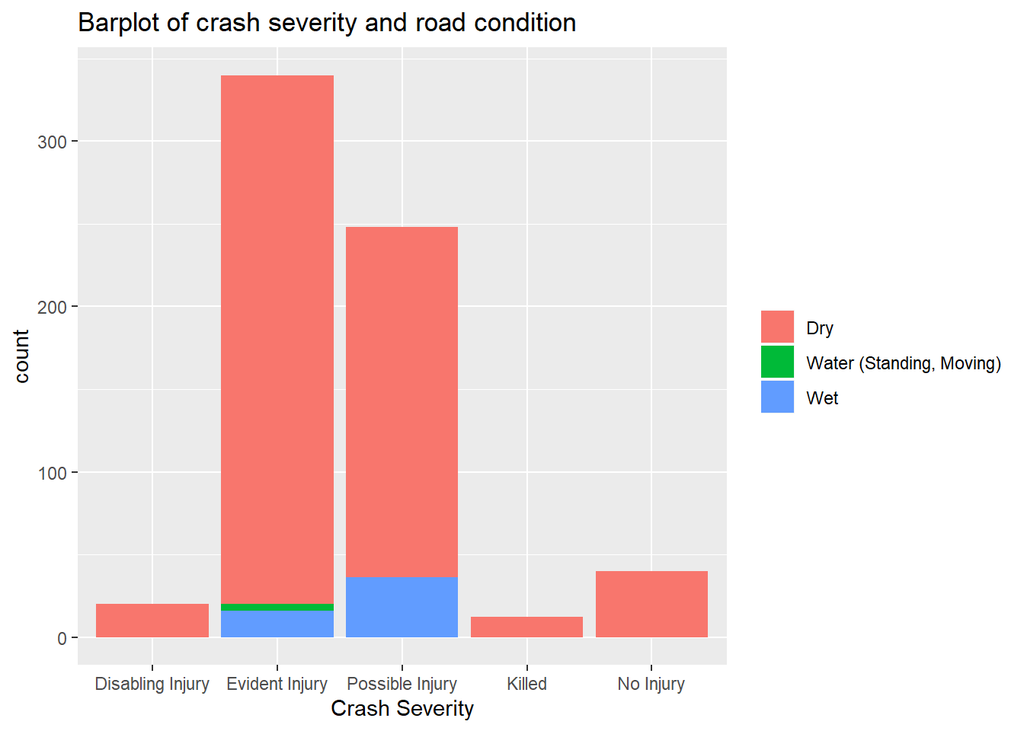

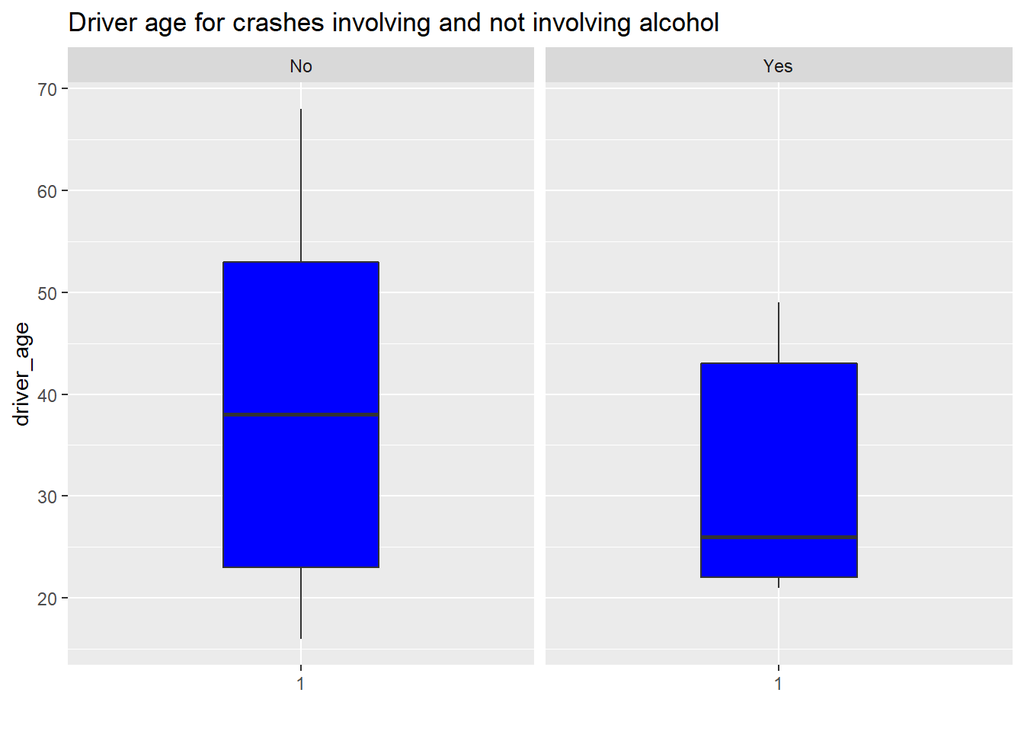

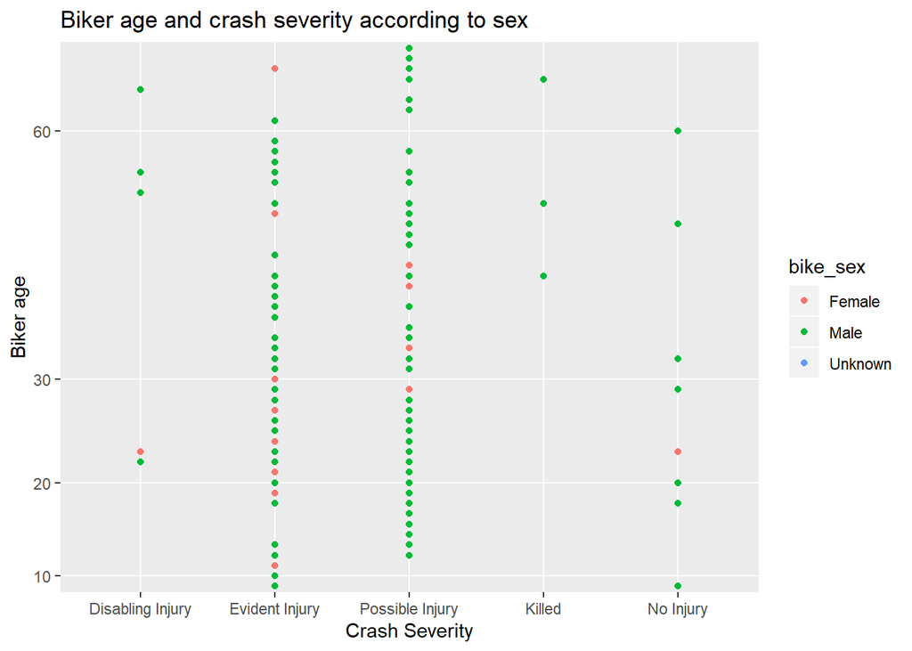

Next, let’s create a function to look at center and spread of age of bicyclists involved in crashes.

```r
my_summary <- function(x){
  mean <- mean(x, na.rm = TRUE)
  stdev <- sd(x, na.rm = TRUE)
return(list(mean,stdev))
}
my_tibble$bike_age <- as.numeric(my_tibble$bike_age)
my_summary <- my_summary(my_tibble$bike_age)
my_summary_nolist <- unlist(my_summary)
summary_matrix <- matrix(my_summary_nolist,ncol = 2)
colnames(summary_matrix) <- c("Mean","Std dev")
summary_matrix
```

```
##          Mean  Std dev
## [1,] 30.42593 14.95663
```

After conducting this initial exploratory data analysis, there are several relationships that could be explored further. For example, we could hypothesize that car accidents involving bicycles are more likely to happen in certain locations. We could also explore whether or not there is a particular combination of factors such as time of year, road condition, age group, and alcohol that could be used to model how likely it is that a fatal crash will occur.